# 数据解释和代码

李家翔

2018-04-15

```r
knitr::opts_chunk$set(message=FALSE, warning=FALSE, eval = F)
library(tidyverse)
library(data.table)
```

# 1 前言

## 1.1 文件注释

```r
dir(file.path(getwd(),"round2_files_upload")) %>%
  as_tibble() %>%
  write_csv(file.path("round2_files","round2_files_upload.csv"))
```

- `http://p24kaozv6.bkt.clouddn.com/round2.2_all_data.csv`: 合并数据，未处理缺失值
- `http://p24kaozv6.bkt.clouddn.com/round2.2_all_miss_perf.csv`: 各股缺失值情况
- `http://p24kaozv6.bkt.clouddn.com/round2.2_cor_sd_lower.csv`: 打榜文件
- `http://p24kaozv6.bkt.clouddn.com/round2.2_cor_z_score_lower.csv`: 打榜文件
- `http://p24kaozv6.bkt.clouddn.com/round2.2_cor_z_score_upper.csv`: 打榜文件
- `http://p24kaozv6.bkt.clouddn.com/round2.2_cor_z_score_zero.csv`: 打榜文件
- `http://p24kaozv6.bkt.clouddn.com/round2.2_data_lag_y_15.csv`: y的连续滞后15期数据
- `http://p24kaozv6.bkt.clouddn.com/round2.2_fcontest_xgboost.model`: xgboost模型文件
- `http://p24kaozv6.bkt.clouddn.com/round2.2_full_data_ipt_miss_mu_sigma_rank_by_3.csv`: 公司聚类标签
- `http://p24kaozv6.bkt.clouddn.com/round2.2_full_data_ipt_miss_wo_scale_part1.csv`: 处理了缺失值的数据
- `http://p24kaozv6.bkt.clouddn.com/round2.2_full_data_ipt_miss_wo_scale_part2.csv`: 处理了缺失值的数据
- `http://p24kaozv6.bkt.clouddn.com/round2.2_hclus_tag.csv`: 公司聚类标签
- `http://p24kaozv6.bkt.clouddn.com/round2.2_history_ensemble.csv`: 打榜文件
- `http://p24kaozv6.bkt.clouddn.com/round2.2_history_perf.csv`: 历史个股表现，基于OOT数据
- `http://p24kaozv6.bkt.clouddn.com/round2.2_imp10_vars_w_lag_15_part1.csv`: x的连续滞后15期数据
- `http://p24kaozv6.bkt.clouddn.com/round2.2_imp10_vars_w_lag_15_part2.csv`: x的连续滞后15期数据
- `http://p24kaozv6.bkt.clouddn.com/round2.2_imp10_vars_w_lag_15_part3.csv`: x的连续滞后15期数据
- `http://p24kaozv6.bkt.clouddn.com/round2.2_imp10_vars_w_lag_15_part4.csv`: x的连续滞后15期数据
- `http://p24kaozv6.bkt.clouddn.com/round2.2_mu_sigma_30.csv`: 打榜文件
- `http://p24kaozv6.bkt.clouddn.com/round2.2_n_miss_cumsum_num_xiaosong.csv`: 各股收盘价缺失情况
- `http://p24kaozv6.bkt.clouddn.com/round2.2_n_miss_cumsum_xiaosong.csv`: 缺失值的分布
- `http://p24kaozv6.bkt.clouddn.com/round2.2_naive_30_2.0.csv`: 打榜文件
- `http://p24kaozv6.bkt.clouddn.com/round2.2_naive_30_3.0.csv`: 打榜文件
- `http://p24kaozv6.bkt.clouddn.com/round2.2_naive_30_4.0.csv`: 打榜文件
- `http://p24kaozv6.bkt.clouddn.com/round2.2_naive_30.csv`: 打榜文件
- `http://p24kaozv6.bkt.clouddn.com/round2.2_three_index_table.csv`: PCA三个大盘指数
- `http://p24kaozv6.bkt.clouddn.com/round2.2_xgboost_30.csv`: 打榜文件

## 1.2 新增

加入浮动目录，方便翻阅。

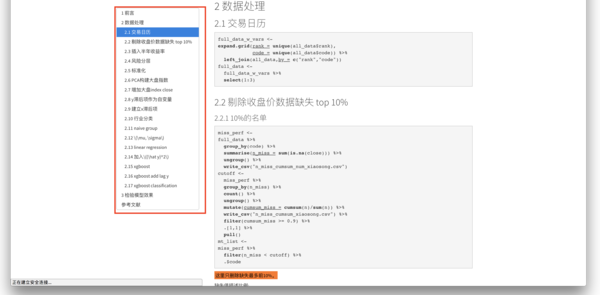

## 1.3 分工

这边底层数据的整理，变量派生，我可以主要来做，大家可以多尝试模型。

## 1.4 反馈两个list

反馈两个list，

- 一个是针对我的`test_data`的，算平均收益率作为打分，
- 另一个是针对$t=488+135$这天的预测，naive模型是不存在的。
- 理论上是有差异的。

## 1.5 比赛要求

比赛对异常值处理要求还是比较高的。

## 1.6 合并数据

### 1.6.1 `round1`和`round2`是否交集为0

这个函数会很慢，不建议跑。

```r
get_data_nest <- function(x){
file.path(getwd(),x) %>%
  dir() %>%
  as_tibble() %>%
  mutate(rank = str_extract(value,"[:digit:]{1,4}"),
         rank = as.integer(rank)) %>%
  arrange(rank) %>%
  mutate(path = file.path(getwd(),x,value)) %>%
  mutate(table = map(path,read_csv))
}

equal_or_not <- function(x,y){
all_data_round1 <- get_data_nest(x)
all_data_round2 <- get_data_nest(y)
all_data_round1_for_join <-
all_data_round1 %>%
  select(value,table) %>%
  rename(table_round1 = table)
all_data_round2_for_join <-
all_data_round2 %>%
  select(value,table) %>%
  rename(table_round2 = table)
all_data_round1_for_join %>%
  left_join(all_data_round2_for_join, by = "value") %>%
  mutate(equal_or_not = map2(table_round1,table_round2,~setequal(.x,.y)[[1]])) %>%
  select(value,equal_or_not) %>%
  unnest()
}
```

```r
equal_or_not("round1","round2")
```

### 1.6.2 合并数据 closed.

```r
all_data <- read_csv(file.path("round2_files","all_data.csv"))
```

# 2 数据处理

## 2.1 交易日历

```r
full_data_w_vars <-
expand.grid(rank = unique(all_data$rank),
            code = unique(all_data$code)) %>%
  left_join(all_data,by = c("rank","code"))
full_data <-
  full_data_w_vars %>%
  select(1:3)
```

## 2.2 剔除收盘价数据缺失 top 10%

### 2.2.1 10%的名单

```r
miss_perf <-
full_data %>%
  group_by(code) %>%
  summarise(n_miss = sum(is.na(close))) %>%
  ungroup() %>%
  write_csv(file.path("round2_files","n_miss_cumsum_num_xiaosong.csv"))
cutoff <-
  miss_perf %>%
  group_by(n_miss) %>%
  count() %>%
  ungroup() %>%
  mutate(cumsum_miss = cumsum(n)/sum(n)) %>%
  write_csv(file.path("round2_files","n_miss_cumsum_xiaosong.csv")) %>%
  filter(cumsum_miss >= 0.9) %>%
  .[1,1] %>%
  pull()
mt_list <-
miss_perf %>%
  filter(n_miss < cutoff) %>%
  .$code
```

这里只删除缺失最多前10%。

```r
f_list <- names(full_data_w_vars) %>% str_subset("f\\d{1,2}|close")
```

### 2.2.2 boxplot outlier detector

```r
remove_outliers <- function(x, na.rm = TRUE, ...) {
  qnt <- quantile(x, probs=c(.25, .75), na.rm = na.rm, ...)
  H <- 1.5 * IQR(x, na.rm = na.rm)
  y <- x
  y[x < (qnt[1] - H)] <- NA
  y[x > (qnt[2] + H)] <- NA
  y
}
```

`Error: Can't create call to non-callable object`: + `funs`[^1]

```r
stable_vars_list <-
full_data_w_vars %>%
  group_by(code) %>%
  summarise_at(f_list,sd, na.rm = TRUE) %>%
  ungroup() %>%
  gather(key,value,f_list) %>%
  group_by(key) %>%
  summarise(mean_sd = mean(value)) %>%
  arrange(mean_sd) %>%
  mutate(mean_sd = (round(mean_sd*1000))) %>%
  filter(mean_sd < 100) %>%
  .$key
```

```r
f_list
stable_vars_list
unstable_vars_list <- setdiff(f_list,stable_vars_list)
unstable_vars_list
```

```r
full_data_outlier2miss <-
  full_data_w_vars %>%
  # 异常值变成NA
    ungroup() %>%
    group_by(code) %>%
  # Inf值直接作为NA
    mutate_at(f_list,function(x){ifelse(is.infinite(x),NA,x)}) %>%
    mutate_at(unstable_vars_list,remove_outliers)
full_data_outlier2miss %>%
  group_by(code) %>%
  summarise_all(funs(sum(is.na(.)))) %>%
  write_csv(file.path("round2_files","all_miss_perf.csv"))
```

```r
full_data_ipt_miss <-
  full_data_outlier2miss %>%
  filter(code %in% mt_list) %>%
  # 缺失值查看
  # summarise_all(funs(sum(is.na(.))))
  ungroup() %>%
  group_by(code) %>%
  tidyr::fill(f_list) %>% # 向下补
  tidyr::fill(f_list, .direction = c("up")) %>% # 向上补
  ungroup()
```

`all_miss_perf.csv`: 异常值$\to$`NA`，`NA`的汇总情况。 下载地址: http://p24kaozv6.bkt.clouddn.com/all_miss_perf.csv

```r
full_data_ipt_miss %>% anyNA()
full_data_ipt_miss %>%
  ungroup() %>%
  summarise_each(funs(sum(is.infinite(.)))) %>%
  gather() %>%
  summarise(sum(value))
```

## 2.3 插入半年收益率

### 2.3.1 逻辑

$$\begin{alignat}{2}
y_t &= F_t \beta + \mu_t \\
y_{t-135} &= F_{t-135} \beta + \mu_{t-135} \\
\Delta y &= \Delta
F_{t-135} \beta + \Delta \mu_{t-135} \\
\end{alignat}$$

类似于CAPM

$r = r_f + \beta_0 (r_{大盘}-r_f) + \mu$

### 2.3.2 $t$的取值范围

我们先定义什么是半年收益率。 假设股价是$P_t$，衡量$t$时刻，某股票价格为$P_t$。 那么它半年后的股价为$P_{t+ 135}$。 那么在$t \in [t,t+135]$时间内的，收益率为$r_t=\frac{P_{t+135}-P_t}{P_t}$。 这个$r_t$衡量了在$t$时刻，以$P_t$价格买入股票，在$t+135$时刻卖出股票，的收益率。

我们知道$t \in [1,488]$，但是同样$t+135 \in [1,488]$。 因此$t \in [1,353]$。 也就是说，我们计算收益率时，

- 买入价$P_t$，必须满足$t \in [1,353]$，同时
- 卖出价$P_{t+135}$，必须满足$t \in [1,353]$，即$t+135 \in [136,488]$。

综上我们保留$t \in [1,353]$的数据。

但是 $P_t$我们使用了$t \in [1,353]$的价格， $P_t$我们使用了$t \in [136,488]$的价格。 因此我们没有少用信息。

### 2.3.3 选择 head

```r
test_y <- seq(20)
test_y
test_y %>% lag(5)
test_y %>% lead(5)
```

### 2.3.4 选择需要处理$\Delta$的因子

### 2.3.5 计算

#### 2.3.5.1 $r=\frac{P_{t+1}-P_t}{P_t}$

```r
full_data_ipt_miss_add_return <-
full_data_ipt_miss %>%
  ungroup() %>%
  # 查看缺失值的情况
      # filter(code == "stock100052") %>%
      # select(rank,code,f58) %>%
      # anyNA()
  group_by(code) %>%
  mutate_at(vars(unstable_vars_list),
            function(x){x = (lead(x+1.001,135)-(x+1.001))/(x+1.001)}) %>%
  filter(!is.na(close)) %>%

  # 探查是否有空值
      # anyNA()
  # 探查出现在哪个变量,f58
      # ungroup() %>%
      # summarise_each(funs(sum(is.na(.)))) %>%
      # gather() %>%
      # arrange(desc(value))
  # 探查出现在哪个股票,stock100052
      # group_by(code) %>%
      # select(rank,code,f58) %>%
      # summarise(sum_na = sum(is.na(f58))) %>%
      # arrange(desc(sum_na))
      # 去表头探查
  # 探查出现在哪个rank,124
      # group_by(rank) %>%
      # select(rank,code,f58) %>%
      # summarise(sum_na = sum(is.na(f58))) %>%
      # arrange(desc(sum_na))
      # 数据本身存在Inf的干扰。
  # Inf占比
      # ungroup() %>%
      # summarise_each(funs(sum(is.infinite(.)))) %>%
      # gather() %>%
      # arrange(desc(value))
  rename(return = close) %>%
  ungroup() %>%
  select(rank,code,return,everything())

# Here, only close price become return.
```

```r
full_data_ipt_miss_add_return_only <-
full_data_ipt_miss %>%
  ungroup() %>%
  # 查看缺失值的情况
      # filter(code == "stock100052") %>%
      # select(rank,code,f58) %>%
      # anyNA()
  group_by(code) %>%
  mutate(
    close = (lead(close+1.001,135)-(close+1.001))/(close+1.001)
      ) %>%
  filter(!is.na(close)) %>%

  # 探查是否有空值
      # anyNA()
  # 探查出现在哪个变量,f58
      # ungroup() %>%
      # summarise_each(funs(sum(is.na(.)))) %>%
      # gather() %>%
      # arrange(desc(value))
  # 探查出现在哪个股票,stock100052
      # group_by(code) %>%
      # select(rank,code,f58) %>%
      # summarise(sum_na = sum(is.na(f58))) %>%
      # arrange(desc(sum_na))
      # 去表头探查
  # 探查出现在哪个rank,124
      # group_by(rank) %>%
      # select(rank,code,f58) %>%
      # summarise(sum_na = sum(is.na(f58))) %>%
      # arrange(desc(sum_na))
      # 数据本身存在Inf的干扰。
  # Inf占比
      # ungroup() %>%
      # summarise_each(funs(sum(is.infinite(.)))) %>%
      # gather() %>%
      # arrange(desc(value))
  rename(return = close) %>%
  ungroup() %>%
  select(rank,code,return,everything())
```

#### 2.3.5.2 doing.$r=\log(\frac{P_{t+1}}{P_t})$

```r
log_return <- function(x){x = log((lead(x+1.001,135))/(x+1.001))}
```

```r
full_data_ipt_miss_add_return_log <-
full_data_ipt_miss %>%
  ungroup() %>%
  # 查看缺失值的情况
      # filter(code == "stock100052") %>%
      # select(rank,code,f58) %>%
      # anyNA()
  group_by(code) %>%
  mutate_at(vars(unstable_vars_list),log_return) %>%
  filter(!is.na(close),!is.nan(close)) %>%

  # 探查是否有空值
      # anyNA()
  # 探查出现在哪个变量,f58
      # ungroup() %>%
      # summarise_each(funs(sum(is.na(.)))) %>%
      # gather() %>%
      # arrange(desc(value))
  # 探查出现在哪个股票,stock100052
      # group_by(code) %>%
      # select(rank,code,f58) %>%
      # summarise(sum_na = sum(is.na(f58))) %>%
      # arrange(desc(sum_na))
      # 去表头探查
  # 探查出现在哪个rank,124
      # group_by(rank) %>%
      # select(rank,code,f58) %>%
      # summarise(sum_na = sum(is.na(f58))) %>%
      # arrange(desc(sum_na))
      # 数据本身存在Inf的干扰。
  # Inf占比
      # ungroup() %>%
      # summarise_each(funs(sum(is.infinite(.)))) %>%
      # gather() %>%
      # arrange(desc(value))
  rename(return = close) %>%
  ungroup() %>%
  select(rank,code,return,everything())
```

```r
# Here, only close price become return.

full_data_ipt_miss_add_return_log_only <-
full_data_ipt_miss %>%
  ungroup() %>%
  # 查看缺失值的情况
      # filter(code == "stock100052") %>%
      # select(rank,code,f58) %>%
      # anyNA()
  group_by(code) %>%
  mutate(
    close = log_return(close)
      ) %>%
  filter(!is.na(close))) %>%

  # 探查是否有空值
      # anyNA()
  # 探查出现在哪个变量,f58
      # ungroup() %>%
      # summarise_each(funs(sum(is.na(.)))) %>%
      # gather() %>%
      # arrange(desc(value))
  # 探查出现在哪个股票,stock100052
      # group_by(code) %>%
      # select(rank,code,f58) %>%
      # summarise(sum_na = sum(is.na(f58))) %>%
      # arrange(desc(sum_na))
      # 去表头探查
  # 探查出现在哪个rank,124
      # group_by(rank) %>%
      # select(rank,code,f58) %>%
      # summarise(sum_na = sum(is.na(f58))) %>%
      # arrange(desc(sum_na))
      # 数据本身存在Inf的干扰。
  # Inf占比
      # ungroup() %>%
      # summarise_each(funs(sum(is.infinite(.)))) %>%
      # gather() %>%
      # arrange(desc(value))
  rename(return = close) %>%
  ungroup() %>%
  select(rank,code,return,everything())
```

#### 2.3.5.3 缺失值再检查

```r
any_miss_infinite <- function(x){
x1 <- x %>% anyNA()
x2 <- x %>%
  ungroup() %>%
  summarise_each(funs(sum(is.infinite(.)))) %>%
  gather() %>%
  summarise(sum(value)) %>%
  pull()
return(c(x1,x2))
}
```

```r
any_miss_infinite(full_data_ipt_miss_add_return)
any_miss_infinite(full_data_ipt_miss_add_return_only)
# any_miss_infinite(full_data_ipt_miss_add_return_log)
# any_miss_infinite(full_data_ipt_miss_add_return_log_only)
```

`unstable_vars_list`有一部分变量出现`0`的情况，因此在计算$\delta$时，会出现$\frac{x_t-x_{t-135}}{0}$的情况，因此对这些变量加1$x \to x+1$。 但是$x=-1$时还是会出现这个问题。 探查数据后，发现都是保留两位小数，因此加$1.001$稳了。 数据中存在$Inf$的情况，因此计算$\Delta$时，会出现`Inf/Inf`无解的情况，直接`fill`掉。

## 2.4 风险分层

```r
full_data_ipt_miss_mu_sigma <-
  full_data_ipt_miss_add_return %>%
  group_by(code) %>%
  summarise(mu = mean(return),sigma = sd(return)) %>%
  mutate(tvalue = mu/sigma)
full_data_ipt_miss_mu_sigma_rank_by_3 <-
full_data_ipt_miss_mu_sigma %>%
  mutate(group = cut_number(abs(tvalue),3),
         group = as.integer(group))
full_data_ipt_miss_mu_sigma_rank_by_3 %>%
  group_by(group) %>%
  count()
```

```r
full_data_ipt_miss_mu_sigma_rank_by_3 %>%
  select(code,group) %>%
  write_csv(file.path("round2_files","full_data_ipt_miss_mu_sigma_rank_by_3.csv"))
```

## 2.5 标准化

```r
dim(full_data_ipt_miss_add_return)
pryr::object_size(full_data_ipt_miss_add_return)
```

```r
part1_index <- 1:round(nrow(full_data_ipt_miss_add_return)/2)
part2_index <- setdiff(1:nrow(full_data_ipt_miss_add_return),part1_index)
```

```r
full_data_ipt_miss_add_return[part1_index,] %>%
  write_csv(file.path("round2_files","full_data_ipt_miss_wo_scale_part1.csv"))
full_data_ipt_miss_add_return[part2_index,] %>%
  write_csv(file.path("round2_files","full_data_ipt_miss_wo_scale_part2.csv"))
```

`full_data_ipt_miss_wo_scale.csv`未标准化数据。

```r
full_data_ipt_miss_add_return %>% anyNA()
```

## 2.6 PCA构建大盘指数

### 2.6.2 详细内容

我们做一个大盘指数，但是我们不知道确定每个股票在大盘中的权重，我们给予一个假设，越重要的权重越高，那么在无监督的情况下，这和PCA的思路非常类似，其他的还有NMF、t-SNE等，抛砖引玉，先搞PCA。 这里主要参考 Conway and White (2012) 和 Hilpisch (2014) 的思路。

> One place where this type of dimensionality reduction is particularly helpful is when dealing with stock market data. (Conway and White 2012)

实际上构建大盘指数的思路就是做降维。

> The first new column, will often contain the vast majority of the structure in the entire data set. PCA is particularly effective when the columns in our data set are all strongly correlated. (Conway and White 2012)

这个大盘指数肯定是描述了我们获得股票数据的最重要的结构。 并且PCA对于处理关联性很高的数据是非常有用的，比如股票，同行业同涨同跌。

```r
rank_n <- unique(full_data_ipt_miss_add_return$rank) %>% length()
rank_n
code_n <- unique(full_data_ipt_miss_add_return$code) %>% length()
code_n
```

```r
pca_matrix <-
  full_data_ipt_miss_add_return %>%
  select(rank,code,return) %>%
  spread(code,return)
```

```r
set.seed(1)
index_no <- sample(1:6,ncol(pca_matrix)-1,replace = TRUE)
index_name <- names(pca_matrix)[-1]
index_table <- data_frame(index_no = index_no, index_name = index_name)
```

```r
index_1 <-
index_table %>%
  filter(index_no == 1) %>%
  .$index_name
index_2 <-
index_table %>%
  filter(index_no == 2) %>%
  .$index_name
index_3 <-
index_table %>%
  filter(index_no == 3) %>%
  .$index_name
index_4 <-
index_table %>%
  filter(index_no == 4) %>%
  .$index_name
index_5 <-
index_table %>%
  filter(index_no == 5) %>%
  .$index_name
index_6 <-
index_table %>%
  filter(index_no == 6) %>%
  .$index_name
```

```r
matrix_1 <- pca_matrix[,c(which(colnames(pca_matrix) %in% index_1))]
matrix_2 <- pca_matrix[,c(which(colnames(pca_matrix) %in% index_2))]
matrix_3 <- pca_matrix[,c(which(colnames(pca_matrix) %in% index_3))]
matrix_4 <- pca_matrix[,c(which(colnames(pca_matrix) %in% index_4))]
matrix_5 <- pca_matrix[,c(which(colnames(pca_matrix) %in% index_5))]
matrix_6 <- pca_matrix[,c(which(colnames(pca_matrix) %in% index_6))]
```

```r
pca_model_1 <- princomp(matrix_1)
pca_model_2 <- princomp(matrix_2)
pca_model_3 <- princomp(matrix_3)
pca_model_4 <- princomp(matrix_3)
pca_model_5 <- princomp(matrix_3)
pca_model_6 <- princomp(matrix_3)
```

> In this summary, the standard deviations tell us how much of the variance in the data set is accounted for by the different principal components. (Conway and White 2012)

如果查看`pca_model_1`会看到每个comp对数据结构的方差的解释，这里我就不列举了，大家可以尝试下。

```r
index_1 <- predict(pca_model_1)[,1]
index_2 <- predict(pca_model_2)[,1]
index_3 <- predict(pca_model_3)[,1]
index_4 <- predict(pca_model_4)[,1]
index_5 <- predict(pca_model_5)[,1]
index_6 <- predict(pca_model_6)[,1]
```

```r
length(index_1)
length(index_2)
length(index_3)
length(index_4)
length(index_5)
length(index_6)
```

```r
three_index_table <-
  data_frame(
    rank = pca_matrix$rank,
    index_1 = index_1,
    index_2 = index_2,
    index_3 = index_3,
    index_4 = index_3,
    index_5 = index_3,
    index_6 = index_3
  )
```

```r
three_index_table %>%
  write_csv(file.path("round2_files","three_index_table.csv"))
```

这个可能得到指数趋势上和真正大盘是负相关，但是没关系，只要我们对其乘以`-1`就好了， 因此PCA得到不同股票的权重，非常优秀。 你们可以left_join使用。

## 2.7 增加大盘index close

逻辑太粗暴，T了。

```
full_data_ipt_miss_add_return <-
full_data_ipt_miss_add_return %>%
  group_by(rank) %>%
  mutate(index = mean(return),
         index_sq = index^2)
```

## 2.8 y滞后项作为自变量

单规则厉害，正说明了y要做自变量。

这里增加15次`lag`滞后项，逐日。 未剔除缺失值，方便大家可以选择少量`lag`滞后项，而不是武断减少1.2610^{4}个自由度。

```r
library(data.table)
data_lag_y_15 <-
full_data_ipt_miss_add_return %>%
   ungroup() %>%
   group_by(code) %>%
   do(data.frame(.,
                 setNames(
                   shift(
                     .$return, 1:15),
                     paste(
                       "return_lag",
                       seq(1:15),
                       sep="_")))) %>%
  select(rank,code,contains("return"))
```

### 2.8.1 检查批量成功进行

```r
data_lag_y_15 %>%
  summarise_all(funs(sum(is.na(.)))) %>%
  head(10)
```

```r
data_lag_y_15 %>%
  write_csv(file.path("round2_files","data_lag_y_15.csv"))
```

## 2.9 建立x滞后项

$\Delta x$效果好，但是选$x$。 我们的目的是任意股票在$t=488+135$时，预测$\hat r_{488+135}$，如果预测足够准，选择最好的20-50个$\hat r_{488+135}$。

这里$r_{488+135} = \frac{P_{488+135}-P_{488}}{P_{488}}$，这里$P_{488}$我们是已知的。 因此我们实际上是预测$P_{488+135}$。

### 2.9.1 使用$\Delta x$进行预测

$$P_{488+135} \sim r_{488+135} \sim \Delta x$$

这里$x$最大取到488， 因此， $\Delta x = \frac{x_{488}-x_{488-135}}{x_{488-135}} \sim x_{488} + x_{488-135}$。 因此我们实际上是用$P_{488+135} \sim x_{488} + x_{488-135}$进行预测。

### 2.9.2 使用$x$进行预测

$$P_{488+135} \sim r_{488+135} \sim x$$

这里$x$最大取到488， 因此， $x = x_{488}$。 因此我们实际上是用$P_{488+135} \sim x_{488}$进行预测。

这也说明了，为什么使用$x$进行预测效果差一些，因为自变量少了一个动量$x_{488-135}$，这个好办，我们可以增加$x_{t-p}$来完成好了。

因此我们选择$x$这样我们可以有更大的自由空间。

这里我会做出$x_{t-1},\cdots,x_{t-15}$给大家使用，这样大家就不用受制于$\Delta x$。

### 2.9.3 代码

因为变量很多，如果全部做`lag(1:15)`，数据表太大，会产生1.2610^{4}个新变量，没有意义，因为我们的数据集不够。 因此根据之前的随机森林结果，取前十importances高的变量做`lag(1:15)`。 `f6, f12, f29, f49, f50, f51, f54, f55, f82, f87`。

```r
imp10_vars <-
  full_data_ipt_miss_add_return %>%
  select(rank,code,f6, f12, f29, f49, f50, f51, f54, f55, f82, f87)
```

```r
dim(imp10_vars)
```

```r
library(data.table)
imp10_vars_w_lag_15 <-
imp10_vars %>%
   group_by(code) %>%
   do(data.frame(.,
                 setNames(shift(.$f6, 1:15), paste("f6_lag",seq(1:15))),
                 setNames(shift(.$f12, 1:15), paste("f12_lag",seq(1:15))),
                 setNames(shift(.$f29, 1:15), paste("f29_lag",seq(1:15))),
                 setNames(shift(.$f49, 1:15), paste("f49_lag",seq(1:15))),
                 setNames(shift(.$f50, 1:15), paste("f50_lag",seq(1:15))),
                 setNames(shift(.$f51, 1:15), paste("f51_lag",seq(1:15))),
                 setNames(shift(.$f54, 1:15), paste("f52_lag",seq(1:15))),
                 setNames(shift(.$f55, 1:15), paste("f55_lag",seq(1:15))),
                 setNames(shift(.$f82, 1:15), paste("f82_lag",seq(1:15))),
                 setNames(shift(.$f87, 1:15), paste("f87_lag",seq(1:15)))
                 ))
```

```r
library(pryr)
object_size(imp10_vars_w_lag_15)
```

```r
names(imp10_vars_w_lag_15) %>% as.tibble()
```

```r
imp10_vars_w_lag_15_partition_index <-
  data.table(index = 1:4,b = 1:nrow(imp10_vars_w_lag_15)) %>%
  select(index)
```

```r
imp10_vars_w_lag_15_partition <-
bind_cols(imp10_vars_w_lag_15,imp10_vars_w_lag_15_partition_index) %>%
  select(index,everything())
```

```r
imp10_vars_w_lag_15_partition %>%
  filter(index == 1) %>%
  write_csv(file.path("round2_files","imp10_vars_w_lag_15_part1.csv"))
imp10_vars_w_lag_15_partition %>%
  filter(index == 2) %>%
  write_csv(file.path("round2_files","imp10_vars_w_lag_15_part2.csv"))
imp10_vars_w_lag_15_partition %>%
  filter(index == 3) %>%
  write_csv(file.path("round2_files","imp10_vars_w_lag_15_part3.csv"))
imp10_vars_w_lag_15_partition %>%
  filter(index == 4) %>%
  write_csv(file.path("round2_files","imp10_vars_w_lag_15_part4.csv"))
```

## 2.10 行业分类

Hierarchical clustering

行业股票存在同涨同跌趋势，因此如果在$t \in [1,488]$期间，股票的涨跌情况大多一致，那么可以认为这是一类股票，大概率属于同行业。 我们使用`hclust()`函数进行聚类。

```r
cluster_data <-
full_data_ipt_miss %>%
  select(code,rank,close) %>%
  group_by(code) %>%
  mutate(daily_return = (close-lag(close))/lag(close)) %>%
  filter(!is.na(daily_return)) %>%
  select(code,rank,daily_return) %>%
  mutate(daily_return = ifelse(daily_return > 0, 1,0)) %>%
  spread(rank,daily_return)
```

现在不同`code`之间，`rank`数量是不一致的，我们只考虑股票都有的情况下，股票之间的相关性。

```r
hclust.out <- hclust(dist(as.matrix(cluster_data[-1])))
```

```r
plot(hclust.out)
```

```r
cluster_tag <- cutree(hclust.out,k = 5)
cluster_tag %>% table()
```

```r
cluster_data %>%
  select(code) %>%
  add_column(hclus_tag = cluster_tag) %>%
  write_csv(file.path("round2_files","hclus_tag.csv"))
```

后续，在这基础上做同行业的PCA，做指数，最后看alpha。

# 3 指标构建思想

## 3.1 收益率>需要normalized和log化

数据存在右偏，log化后，减少偏度。 要normalize的处理，保证数据更加符合标准正态分布。

> **log returns** are additive but __scaled percent returns __aren’t. In other words, the five-day log return is the sum of the five one-day log returns. This is often computationally handy. (Schutt and O’Neil 2013)

并且使用log return是因为其具备可加性。

其次，七增减对称。

```r
log(1-0.5)
log(1+1)
```

之间转换很近似。

$$\begin{alignat}{2}
\log(x) &= \sum_{n}\frac{(x-1)^n}{n} = (x-1) - \frac{(x-1)^2}{2} + \cdots\\
\text{log returns}&=\text{scaled percent returns}-\frac{(x-1)^2}{2} + \cdots\\
\end{alignat}$$

```r
data_frame(x = seq(0.01,5,by = 0.01)) %>%
  mutate(log_x = log(x),
         x_1 = x-1) %>%
  gather(key,value,-x) %>%
  ggplot(aes(x = x,y=value,col=key)) +
    geom_line()
```

在$x=1$处非常近似。 这里的x = $\frac{P_t}{P_{t-1}}$

## 3.2 风险>权重衰减

风险度量我们可以直接使用标准差，但是我们想尽可能的表现距离近的影响大于距离远的影响。 Exponential Downweighting(Schutt and O’Neil 2013)是解决办法之一。 这里类似于现金流预测，加入一个折现率$s$。

$$\begin{alignat}{2}
\text{Var}_{old} &= \frac{\sum_i s^i \cdot r_i^2}{\sum_i s^i}\\
&=\frac{\sum_i s^i \cdot r_i^2}{\frac{1}{1-s}}\\
&=(1-s)\sum_i s^i \cdot r_i^2\\
\end{alignat}$$

$$\text{Var}_{new} = s\text{Var}_{old} + (1-s)r_0^2$$

$r_0$表示当期的收益率，假设$E(r_0)=0$，因此$\text{Var}(r_0) = E(r_0-E(r_0))^2=r_0^2$

这个$s$一般可以用0$.97$等近似于但小于1的数假设。

## 3.3 使用先验信息

类似于AR模型，我们使用$y_{t-p}$预测$y_t$，但是这一次我们将其写入损失函数中。(Schutt and O’Neil 2013)

$$\begin{alignat}{2}
L &= \sigma(y-\hat y) + \gamma(\beta) + \rho(\beta_j-\beta_{j+1})\\
&\begin{cases}
\sigma(y-\hat y) &\sim \frac{1}{N}\sum_i (y-x\beta)^2 &\sim \text{RMSE}\\
\gamma(\beta) &\sim \sum_j(\beta)^2 &\sim \text{正则化}\\
\rho(\beta_j-\beta_{j+1}) &\sim \sum_j(\beta_j-\beta_{j+1})^2 &\sim \text{smoothing}\\
\end{cases}
\end{alignat}$$

> adjacent coefficients should be not too different from each other. (Schutt and O’Neil 2013)

$\rho(\beta_j-\beta_{j+1})$要求我们可以用滞后项去预测，但是中间的自相关系数不能跳变太大，否则不符合我们的直觉。 但是这样构建一个函数处理，但是我目前没看到包直接可以调用这种损失函数。

# 4 模型方法

## 4.1 naive group

### 4.1.1 naive

我是相当于每个rank，选出半年收益率最高的五十个，最后汇总起来，哪个股票出现频次越多，就越容易选上。但是最后我只选前30，这个数字只是好奇的选的。

$$\begin{alignat}{2}
\forall i: \frac{P_{488+135}^{i}-P_{488}^{i}}{P_{488}^{i}} = r_{488}^{i} &\sim f^{i}(r_1,\cdots,r_{353})\\
&\sim \sum_{j=1}^{353}\mathcal I(r_j^i \text{ is top 50}) = \\
&\to \text{choose top 30} \hat f^{i}(r_1,\cdots,r_{353})
\end{alignat}$$

因此这里实际上把回归问题转化为一个分类问题$\mathcal I(r_j^i \text{ is top 50})$，但是也还是只用了$r$的信息，没有使用$x$，正说明了滞后项、$r$信息很重要。

$$\mathcal I(y) =
\begin{cases}
1&\text{, y is true}\\
0&\text{, y is false}\\
\end{cases}$$

```r
all_data %>%
  # names()
  select(1:3) %>%
  group_by(code) %>%
  mutate(close_lag = lag(close,135)) %>%
  filter(!is.na(close_lag)) %>%
  mutate(return = (close-close_lag)/close_lag*100) %>%
  ungroup() %>%
  # distinct(rank)
  group_by(rank) %>%
  top_n(50,return) %>%
  ungroup() %>%
  group_by(code) %>%
  count() %>%
  arrange(desc(n)) %>%
  ungroup() %>%
  top_n(30,n) %>%
  write_csv(file.path("round2_files","naive_30.csv")) %>%
  select(everything())
```

### 4.1.2 naive 2.0

```r
full_data_ipt_miss %>%
  group_by(code) %>%
  mutate(close_lag = lag(close,135)) %>%
  filter(!is.na(close_lag)) %>%
  mutate(return = (close-close_lag)/close_lag*100) %>%
  ungroup() %>%
  # distinct(rank)
  group_by(rank) %>%
  top_n(50,return) %>%
  ungroup() %>%
  group_by(code) %>%
  count() %>%
  arrange(desc(n)) %>%
  ungroup() %>%
  top_n(30,n) %>%
  write_csv(file.path("round2_files","naive_30_2.0.csv")) %>%
  select(everything())
```

- [r - group_by() into fill() not working as expected - Stack Overflow](https://stackoverflow.com/questions/34517370/group-by-into-fill-not-working-as-expected)

### 4.1.3 naive 3.0

```r
library(TTR)
```

```r
a <- seq(20)
a
SMA(a,6)
```

移动平均: 对的，相当于我做了稳定性处理，也就是说这个处理过的收益率是吸收了风险的。

```r
unique_rank <-
all_data %>%
  group_by(code) %>%
  count() %>%
  arrange(n) %>%
  filter(n > 158)

all_data %>%
  filter(code %in% unique_rank$code) %>%
  group_by(code) %>%
  mutate(close_lag = lag(close,135)) %>%
  filter(!is.na(close_lag)) %>%
  mutate(return = (close-close_lag)/close_lag*100) %>%
  mutate(return_SMA_7 = SMA(return,7)) %>%
  select(rank,code,return,return_SMA_7) %>%
  filter(!is.na(return_SMA_7)) %>%
  ungroup() %>%
  # distinct(rank)
  group_by(rank) %>%
  top_n(50,return_SMA_7) %>%
  ungroup() %>%
  group_by(code) %>%
  count() %>%
  arrange(desc(n)) %>%
  ungroup() %>%
  top_n(30,n) %>%
  write_csv(file.path("round2_files","naive_30_3.0.csv")) %>%
  select(everything())
```

### 4.1.4 naive 4.0

我们发现在naive的答案中，第一个是最naive的，但是还是非常坚挺的。 我觉得可以控制`i`和`j`两个`top_n`的参数或许得到提升，这是一个最优化的问题， 最后感觉的确得到了提升。

```r
valid_avg_return <-
full_data_ipt_miss_add_return %>%
  filter(rank > 117,rank < 235) %>%
  select(rank,code,return) %>%
  group_by(code) %>%
  summarise(return = mean(return))
```

```r
choose_best_boundary <- function(i,j){
all_data %>%
  # names()
  select(1:3) %>%
  group_by(code) %>%
  mutate(close_lag = lag(close,135)) %>%
  filter(!is.na(close_lag)) %>%
  mutate(return = (close-close_lag)/close_lag*100) %>%
  ungroup() %>%
  # distinct(rank)
  group_by(rank) %>%
  top_n(i,return) %>%
  ungroup() %>%
  group_by(code) %>%
  count() %>%
  arrange(desc(n)) %>%
  ungroup() %>%
  top_n(j,n) %>%
  left_join(valid_avg_return,by="code") %>%
  summarise(mean(return)) %>%
  pull()
}
```

```r
grid_boundary <-
expand.grid(i = seq(20,25,1), j = seq(20,25,1)) %>%
  mutate(return = map2_dbl(i,j,choose_best_boundary))
```

```r
grid_boundary %>%
  arrange(desc(return))
```

```r
all_data %>%
  # names()
  select(1:3) %>%
  group_by(code) %>%
  mutate(close_lag = lag(close,135)) %>%
  filter(!is.na(close_lag)) %>%
  mutate(return = (close-close_lag)/close_lag*100) %>%
  ungroup() %>%
  # distinct(rank)
  group_by(rank) %>%
  top_n(21,return) %>%
  ungroup() %>%
  group_by(code) %>%
  count() %>%
  arrange(desc(n)) %>%
  ungroup() %>%
  top_n(21,n) %>%
  write_csv(file.path("round2_files","naive_30_4.0.csv")) %>%
  select(everything())
```

## 4.2 $\mu, \sigma$

```r
full_data_ipt_miss_mu_sigma %>%
  arrange(desc(tvalue)) %>%
  head(30) %>%
  write_csv(file.path("round2_files","mu_sigma_30.csv"))
```

## 4.3 linear regression

### 4.3.1 SUR close

相比较于面板数据的模型，考虑了个体效应，SUR还允许了不同个体拥有不同的$\beta$。

Unlike the panel data models considered in the preceding section, which permit only individual-specific intercepts, the SUR model also allows for individual-specific slopes. (Kleiber and Zeileis 2008)

```
library(systemfit)
code_choice <- full_data_ipt_miss_wo_scale %>% distinct(code) %>% .$code %>% head(50)
test_SUR <- subset(full_data_ipt_miss_wo_scale, code %in% code_choice)
library(plm)
test_SUR_plm <- plm.data(test_SUR, c("code","rank"))
test_SUR_model <- systemfit(return ~ f1, method = "SUR", data = test_SUR_plm)
```

`Error in LU.dgC(a) : cs_lu(A) failed: near-singular A (or out of memory)`

```
library(broom)
for (i in seq(length(code_choice))){
summary(test_SUR_model)$eq[[i]]$coefficients %>% as.data.frame() %>% print()
}
```

### 4.3.2 OLS

#### 4.3.2.1 get $\Delta x$

##### 4.3.2.1.1 控制id和f的数量

```r
code_limit <-
  full_data_ipt_miss_add_return %>%
  ungroup() %>%
  distinct(code) %>%
  .$code %>%
  head(2+1000)
f_limit <-
  names(full_data_ipt_miss_add_return) %>%
  str_subset("code|f\\d{1,2}|return|index") %>%
  head(2+1000)
```

#### 4.3.2.2 get x close

我想过是不是因为$\Delta x$和$x$不一样导致的，但是我用`biglm`作为例子试过了，发现并非如此。 这个猜想无效的。

这也解释了为什么xgboost效果也不行，因为$x$是trivial的。

#### 4.3.2.3 modeling

```r
model_text <-
paste("return",
      f_limit %>% str_subset("f|index") %>% paste(collapse = "+"),
      sep = "~")
```

```
dataset_big_ols <- function(x){
  x %>%
    select(f_limit) %>%
    filter(code %in% code_limit)
}
test_big_OLS <- dataset_big_ols(full_data_ipt_miss_add_return)
test_big_OLS_return_only <- dataset_big_ols(full_data_ipt_miss_add_return_only)
library(biganalytics)
library(broom)

get_ols_output <- function(x){
  x %>%
    group_by(code) %>%
    nest() %>%
    mutate(model = map(data,
                       function(df){biglm(as.formula(model_text), data = df) %>%
                       # function(df){biglm(return ~.,
                       #                    data = df %>%
                       #                      select_if(function(y){n_distinct(y)>1})
                           tidy()})) %>%
    select(code,model) %>%
    unnest() %>%
    filter(term == "(Intercept)") %>%
    arrange(desc(estimate))
}

ols_alpha_output <- get_ols_output(test_big_OLS)
# ols_alpha_output_return_only <- get_ols_output(test_big_OLS_return_only)
```

`select_if(function(y){n_distinct(y)>1})` 这个地方的报错没有解决， `Error in mutate_impl(.data, dots) : variable 'y' not found` 原因是这个变量不能识别。

`Error in mutate_impl(.data, dots) : Evaluation error: NA/NaN/Inf in foreign function call (arg 3).` `ols_alpha_output_return_only`run不出来。

#### 4.3.2.4 perf

```
library(broom)
get_ols_perf <- function(x){
  x %>%
    group_by(code) %>%
    nest() %>%
    mutate(model = map(data,
                       function(df){biglm(as.formula(model_text), data = df) %>%
                           glance()})) %>%
    select(code,model) %>%
    unnest()
}
ols_alpha_perf <- get_ols_perf(test_big_OLS)
ols_alpha_perf_return_only <- get_ols_perf(test_big_OLS_return_only)
```

```
ols_alpha_perf %>%
  select(code,r.squared) %>%
  rename(rsq = r.squared) %>%
  left_join(
    ols_alpha_perf_return_only %>%
      select(code,r.squared) %>%
      rename(rsq_only = r.squared),
    by = "code"
  ) %>%
  mutate(delta_rsq = rsq-rsq_only) %>%
  ggplot(aes(x = delta_rsq)) +
    geom_freqpoly()
```

$\Delta x$效果明显强于$x$，比较每个`code`的$R^2$。 但是我们无法get $t = 488$这天的$\Delta x$只有$x$。 但是实际上，我们拿到的$\Delta x$也包含了$x_{488}$和$x_{488-135}$的信息，没差，可能就是说$\Delta x$是相减得到的，损失了一部分信息，但是如果这个剪完就是0了，说明这个变量很稳定，对y的预测效果很少啊。 所以还是follow$\Delta x$的思路。

```
ols_alpha_output %>%
  filter(p.value < 0.05) %>%
  top_n(30,estimate) %>%
  write_csv("biglm_alpha_top_30.csv")
ols_alpha_output_return_only %>%
  filter(p.value < 0.05) %>%
  top_n(30,estimate) %>%
  write_csv("biglm_alpha_top_30_return_only.csv")
```

SUR模型在Python和R上都失败了，这里使用`biglm`建立各公司之间独立的OLS回归，找$\alpha$最大的前30.

`biglm_alpha_top_30.csv` 数据下载地址, http://p24kaozv6.bkt.clouddn.com/biglm_alpha_top_30.csv

## 4.4 加入${\hat y}^2$

考虑平方项

## 4.5 xgboost

### 4.5.1 import data

```r
full_data_ipt_miss_wo_scale <- full_data_ipt_miss_add_return
```

```r
dim(full_data_ipt_miss_wo_scale)
dim(three_index_table)
```

### 4.5.2 train test split

```r
full_data_ipt_miss_wo_scale_add_three <-
full_data_ipt_miss_wo_scale %>%
  left_join(three_index_table,by="rank")
xgboost_train <- full_data_ipt_miss_wo_scale_add_three %>% filter(rank <= 117)
xgboost_valid <- full_data_ipt_miss_wo_scale_add_three %>%
  filter(rank > 117, rank <= 235)
xgboost_test  <- full_data_ipt_miss_wo_scale_add_three %>% filter(rank > 235)
```

### 4.5.3 dmatrix

```r
library(xgboost)
get_dmatrix <- function(x){
  xgb.DMatrix(data = as.matrix(x %>% select(-code,-return)),
              label = x$return)
}
xgboost_dtrain <- get_dmatrix(xgboost_train)
xgboost_dvalid <- get_dmatrix(xgboost_valid)
xgboost_dtest <- get_dmatrix(xgboost_test)

watchlist  <- list(train = xgboost_dtrain,
                    test = xgboost_dvalid)
```

### 4.5.4 modeling

```r
xgb <- xgb.train(
 data               = xgboost_dtrain,
 # 1
   eta              = 0.1,
   nround           = 2000,
   # 这里也是没有办法，为了调整参数，所以设置了很高的学习率，nround少于100次
   # 最后可以尝试更低的。
 # 2
   max_depth        = 7,
   min_child_weight = 17,
   gamma            = 0.72,
 # 3
   subsample        = 0.8,
   colsample_bytree = 0.95,
 # 评价标准
   # eval.metric    = "error",
   # eval.metric    = "rmse",
   # eval.metric    = ks_value,
   # eval.metric      = "auc",
   # eval.metric    = "logloss",
 # objective
   objective        = "reg:linear", # 这是一个回归问题
 # 其他
   seed             = 123,
   watchlist        = watchlist,
   # 300万数据一起用！
   nfold            = 5,
   early.stop       = 50,
   nthread          = 8
   )
```

```r
library(pryr)
object_size(xgb)
xgb.save(xgb, file.path("round2_files","fcontest_xgboost.model"))
```

### 4.5.5 perf

```r
fcontest_xgb <- xgb.load(file.path("round2_files","fcontest_xgboost.model"))
```

```r
library(xgboost)
length(predict(fcontest_xgb,xgboost_dvalid))
dim(xgboost_valid)
```

```r
xgboost_valid_add_yhat <-
xgboost_valid %>%
  select(rank,code,return) %>%
  add_column(return_pred = predict(fcontest_xgb,xgboost_dvalid))
```

```r
xgboost_30_list <-
xgboost_valid_add_yhat %>%
  group_by(rank) %>%
  top_n(50,return_pred) %>%
  ungroup() %>%
  group_by(code) %>%
  count() %>%
  ungroup() %>%
  arrange(desc(n)) %>%
  top_n(30,n) %>%
  write_csv(file.path("round2_files","xgboost_30.csv"))
```

```r
xgboost_30_list
```

## 4.6 xgboost add lag y

## 4.7 xgboost classification

## 4.8 引入相关性

```r
library(tidyverse)
library(reshape2)
cor_list <- function(x) {
  L <- M <- cor(x)

  M[lower.tri(M, diag = TRUE)] <- NA
  M <- melt(M)
  names(M)[3] <- "points"
  # lower.tri就是i比j大，而已。
  L[upper.tri(L, diag = TRUE)] <- NA
  L <- melt(L)
  names(L)[3] <- "labels"

  merge(M, L)
}


read_csv(file.path("round2_files","naive_30_3.0.csv")) %>%
  select(code) %>%
  left_join(full_data_ipt_miss_add_return, by = "code") %>%
  select(code,rank,return) %>%
  spread(code,return) %>%
  select(-rank) %>%
  do(cor_list(.)) %>%
  select(1:3) %>%
  filter(!is.na(points)) %>%
  group_by(Var1) %>%
  summarise(avg_cor = mean(points),sd_cor = sd(points),
            z_cor = avg_cor/sd_cor) %>%
  arrange(abs(z_cor))
  # arrange(z_cor)
  # arrange(sd_cor)
```

```r
read_csv(file.path("round2_files","naive_30_3.0.csv")) %>%
  filter(code != "stock102109") %>%
  write_csv(file.path("round2_files","cor_z_score_lower.csv"))
read_csv(file.path("round2_files","naive_30_3.0.csv")) %>%
  filter(code != "stock102853") %>%
  write_csv(file.path("round2_files","cor_z_score_upper.csv"))
read_csv(file.path("round2_files","naive_30_3.0.csv")) %>%
  filter(code != "stock101155") %>%
  write_csv(file.path("round2_files","cor_z_score_zero.csv"))
read_csv(file.path("round2_files","naive_30_3.0.csv")) %>%
  filter(code != "stock102253") %>%
  write_csv(file.path("round2_files","cor_sd_lower.csv"))
```

# 5 检验模型效果

```r
test_data <-
full_data_ipt_miss_wo_scale %>%
  filter(rank > 235) %>%
  select(rank,code,return)
```

这里$t \in [1,353]$，其中$t \in [236,353]$作为测试组。

## 5.1 `Geometric Mean Return`

$$\bar r_g = \prod_{i=1}^{353}(1+r_i)-1$$

idea主要参考 Boudt, Dirick, and Parry (n.d.)， 构建参考: [r - Geometric Mean: is there a built-in? - Stack Overflow](https://stackoverflow.com/questions/2602583/geometric-mean-is-there-a-built-in)

```r
gmean_r <- function(x){(exp(mean(log(x/100+1)))-1)*100}
```

这里的`x`的单位是`%`

```r
model_proc <- function(x){
  x <- file.path("round2_files",x)
code_blanket <-
  read_csv(x) %>% select(code)
model_table  <-
  code_blanket %>%
  left_join(test_data,by="code") %>%
  select(code,rank,return)
model_perf <-
  model_table %>%
  summarise(gmean_r(return)) %>%
  pull()
model_perf_text <- paste(x,":",as.character(round(model_perf*10000)/10000),"%")
return(list(code_blanket,model_table,model_perf_text))
}
```

`model_proc`是一个`list`，第一项是选择的code，第二项是left join的`rank`和`return`后的表，第三项是平均收益率。

```r
naive_30           <- model_proc("naive_30.csv")
naive_30_2.0       <- model_proc("naive_30_2.0.csv")
naive_30_3.0       <- model_proc("naive_30_3.0.csv")
naive_30_4.0       <- model_proc("naive_30_4.0.csv")
mu_sigma_30        <- model_proc("mu_sigma_30.csv")
# biglm_alpha_top_30 <- model_proc("biglm_alpha_top_30.csv")
# biglm_alpha_top_30_return_only <- model_proc("biglm_alpha_top_30_return_only.csv")
# wu_20180401        <- model_proc("wu_20180401.csv")
# wu_20180402        <- model_proc("wu_20180402.csv")
# wu_20180402_2      <- model_proc("wu_20180402_2.csv")
# wu_20180404        <- model_proc("wu_20180404.csv")
# wu_20180405        <- model_proc("wu_20180405.csv")
# xiaosong_20180405  <- model_proc("xiaosong_20180405.csv")
xgboost_30         <- model_proc("xgboost_30.csv")
history_ensemble   <- model_proc("history_ensemble.csv")
```

```r
naive_30[[3]]
naive_30_2.0[[3]]
naive_30_3.0[[3]]
naive_30_4.0[[3]]
mu_sigma_30[[3]]
# biglm_alpha_top_30[[3]]
# biglm_alpha_top_30_return_only[[3]]
# wu_20180401[[3]]
# wu_20180402[[3]]
# wu_20180402_2[[3]]
# wu_20180404[[3]]
# wu_20180405[[3]]
# xiaosong_20180405[[3]]
xgboost_30[[3]]
# history_ensemble[[3]]
```

我验证了一波，的确第一次的收益率在测试组中是最高的，37%%半年收益率。我发现，单规则粗暴一点效果还可以， 但是加入X后，不能粗暴的跑`biglm`，结果非常差，收益率几乎为0. 跑模型一定要精细化。

```r
add_name <- function(x,y){
  x[[1]] %>% mutate(type = y)
}
```

```r
code_selection_by_all_model_long <-
bind_rows(
add_name(naive_30,"naive_30"),
add_name(naive_30_2.0,"naive_30_2.0"),
add_name(naive_30_3.0,"naive_30_3.0"),
add_name(naive_30_3.0,"naive_30_4.0"),
add_name(mu_sigma_30,"mu_sigma_30"),
# add_name(biglm_alpha_top_30,"biglm_alpha_top_30_code"),
# add_name(biglm_alpha_top_30_return_only,"biglm_alpha_top_30_code_return_only"),
# add_name(wu_20180401,"wu_20180401"),
# add_name(wu_20180402,"wu_20180402"),
add_name(xgboost_30,"xgboost_30"),
add_name(history_ensemble,"history_ensemble")
)
code_selection_by_all_model_wide <-
code_selection_by_all_model_long %>%
  mutate(value = 1) %>%
  spread(type,value)
```

## 5.2 历史平均法

```r
history_ensemble <-
code_selection_by_all_model_long %>%
  group_by(code) %>%
  count() %>%
  arrange(desc(n)) %>%
  ungroup() %>%
  top_n(30,n) %>%
  write_csv(file.path("round2_files","history_ensemble.csv"))
```

```r
history_perf <-
test_data %>%
  group_by(code) %>%
  summarise(mean = mean(return),sd = sd(return)) %>%
  arrange(desc(mean),sd) %>%
  left_join(code_selection_by_all_model_wide, by = "code") %>%
  write_csv(file.path("round2_files","history_perf.csv"))
history_perf %>% head(10)
```

```r
save.image()
```

# 参考文献

Boudt, Kris, Lore Dirick, and Josiah Parry. n.d. “Https://Www.datacamp.com/Courses/Introduction-to-Portfolio-Analysis-in-R.” DataCamp.

Conway, Drew, and John White. 2012. *Machine Learning for Hackers Case Studies and Algorithms to Get You Started*. O’Reilly Media. http://shop.oreilly.com/product/0636920018483.do.

Hilpisch, Yves. 2014. *Python for Finance: Analyze Big Financial Data*. O’Reilly Media, Inc.

Kleiber, Christian, and Achim Zeileis. 2008. *Applied Econometrics with R*. Springer New York.

Schutt, Rachel, and Cathy O’Neil. 2013. *Doing Data Science: Straight Talk from the Frontline*. O’Reilly Media, Inc.

[^1]: [r - Summarize with conditions and implicit column names in dplyr - Stack Overflow](https://stackoverflow.com/questions/48025994/summarize-with-conditions-and-implicit-column-names-in-dplyr)